# Ciclystic Company Analysis

Data Analysis about rides travels from Ciclystic Company

Walber Rodriguez

2025-04-24

# Final Project

### Coursera - Google Data Analyst

This is my final project for Coursera Certification about **Google Data Analyst**

For this analysis, It was created many information regarding 6 months of records from Ciclystic Co.

- Member Type (Member / Casual)
- Ride Type (Classic / Electric)

```
## here() starts at C:/Users/WRodriguez/OneDrive/Documentos
```

#### Let’s see some analysis regarding the dataset about Ciclystic Co.

##### Above you can see some information and insights.

How many rides were done by each Member Type by bike type on 6 months?

```r
# This tiblle shows the number of rides per riders and bike types
# rides_num6m <- ciclystic_6mc %>%
#  count(member_casual, rideable_type)
  rides_num6m
```

```
##   member_casual rideable_type num_rides
## 1        casual  classic_bike    126436
## 2        casual electric_bike    142007
## 3        member  classic_bike    189394
## 4        member electric_bike    199906
```

Show the graphic about number of rides by each Member Type only

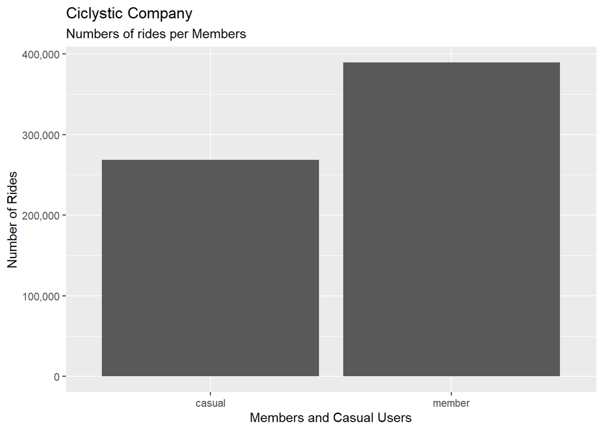

```r
# This plot shows graphically the number of rides
#plot_num_rides6m <- ggplot(ciclystic_6mc) +
#  geom_bar(mapping = aes(x = member_casual)) +
#  labs(title = "Ciclystic Company", subtitle = "Numbers of rides per Members") +
#  labs(x = "Members and Casual Users", y = "Number of Rides") +
#  scale_y_continuous(labels = scales::comma)
  plot(plot_num_rides6m)
```

In this plot, you can see the number of rides per Members and Rideables Types, according above:

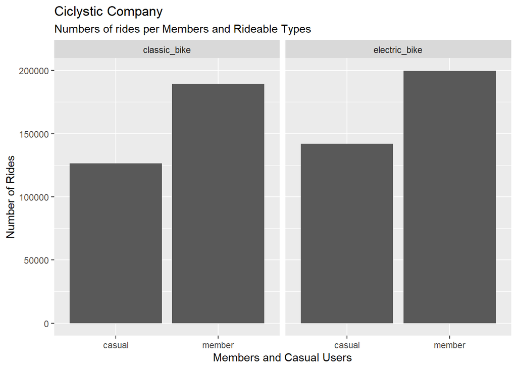

```r
# Plot that shows separated graphics for Type of Rides and Members
#plot_num_rides16m <- ggplot(ciclystic_6mc) +
#  geom_bar(mapping = aes(x = member_casual)) +
#  facet_wrap(~rideable_type) +
#  labs(title = "Ciclystic Company", subtitle = "Numbers of rides per Members and Rideable Types") +
#  labs(x = "Members and Casual Users", y = "Number of Rides")
plot(plot_num_rides16m)
```

How is the average Time used by each Member Type? (in Minutes)

```r
# This tiblle shows the average time in minutes per riders
#ride_avg_member6m <- ciclystic_6mc %>%
#  group_by(member_casual) %>%
#  summarize(ride_avg = mean(ride_min))
  ride_avg_member6m
```

```
## # A tibble: 2 × 2
##   member_casual ride_avg
##   <chr>         <drtn>
## 1 casual        37.09696 secs
## 2 member        22.11206 secs
```

#### Analysis

This is the respective graphic regarding this summary about Member Types:

```
## Defaulting to continuous.
```

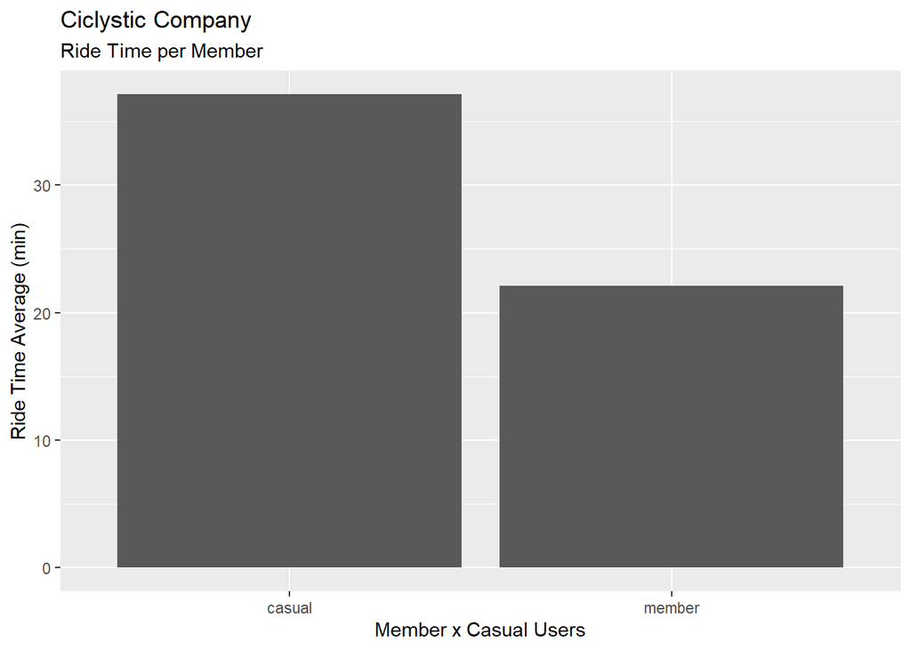

```r
# This plot shows the average time of using bikes per riders in Minutes
#plot_ride_avg_member6m <- ggplot(ride_avg_member6m, aes(member_casual, ride_avg)) +
#  geom_bar(stat = "identity", position = 'dodge') +
#  labs(title = "Ciclystic Company", subtitle = "Ride Time per Member") +
#  labs(x = "Member x Casual Users", y = "Ride Time Average (min)")
  plot(plot_ride_avg_member6m)
```

How is the Average Ride Time per each Member Type (In Minutes):

```r
# This tiblle shows the average time by bike types per riders
#ride_avg_member16 <- ciclystic_6mc %>%
#  group_by(member_casual, rideable_type) %>%
#  summarize(ride_avg = mean(ride_min))
  ride_avg_member16
```

```
## # A tibble: 4 × 3
## # Groups:   member_casual [2]
##   member_casual rideable_type ride_avg
##   <chr>         <chr>         <drtn>
## 1 casual        classic_bike  47.81599 secs
## 2 casual        electric_bike 27.55327 secs
## 3 member        classic_bike  23.78167 secs
## 4 member        electric_bike 20.53025 secs
```

#### Analysis

Classic Bike = 71.59 min - 60% Eletric Bike = 48.08 min - 40% Total = 1,19.67 min

Casual User = 75.36 min - 63% Member User = 44.31 min - 37% Total = 1,19.67 min

And, the plot showing how Members are using each type of Bike:

```
## Defaulting to continuous.
```

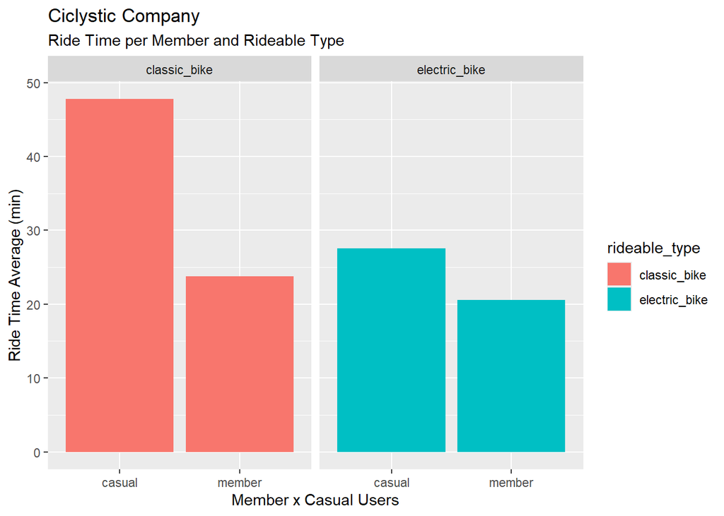

```r
# This plot shows the average time rider by bike types
#plot_ride_avg_member16 <- ggplot(ride_avg_member16, aes(member_casual, ride_avg, fill = rideable_type)) +
#  geom_bar(stat = "identity", position = 'dodge') +
#  facet_wrap(~rideable_type) +
#  labs(title = "Ciclystic Company", subtitle = "Ride Time per Member and Rideable Type") +
#  labs(x = "Member x Casual Users", y = "Ride Time Average (min)")
plot(plot_ride_avg_member16)
```

In another insight, above you can see:

How is the Average Ride Distance used by each Member Type only (in KM):

```r
# This tiblle shows the average distance covered per rider
#ride_dist_member6 <- ciclystic_6mc %>%
#  group_by(member_casual) %>%
#  summarise(avg_dist = mean(ride_distance))
  ride_dist_member6
```

```
## # A tibble: 2 × 2
##   member_casual avg_dist
##   <chr>            <dbl>
## 1 casual            1.20
## 2 member            1.23
```

How are the results of TIme and Distance mixed by Users and bikes?

```r
# This tibble shows the information (Times and Distances) mixed between Users and Bikes
#rides_avg_mix6 <- ciclystic_6mc %>%
#  group_by(member_casual, rideable_type) %>%
#  summarize(avg_time = mean(ride_min), avg_dist = mean(ride_distance))
  rides_avg_mix6
```

```
## # A tibble: 4 × 4
## # Groups:   member_casual [2]
##   member_casual rideable_type avg_time      avg_dist
##   <chr>         <chr>         <drtn>           <dbl>
## 1 casual        classic_bike  47.81599 secs     1.12
## 2 casual        electric_bike 27.55327 secs     1.26
## 3 member        classic_bike  23.78167 secs     1.06
## 4 member        electric_bike 20.53025 secs     1.38
```

#### Analysis

Total Average Distance 4.83 km The Member type is riding (2.44) 51% of total average distance, instead; the Casual user that is riding (2.38) 49% of. Note: The distance is measured between start location and end location coordinates. ——————————————————————————–

This is the respective plot regarding this summary about Member Types:

```r
# This tiblle shows the average distance covered per riders
#ride_dist_member6 <- ciclystic_6mc %>%
#  group_by(member_casual) %>%
#  summarise(avg_dist = mean(ride_distance))
  ride_dist_member6
```

```
## # A tibble: 2 × 2
##   member_casual avg_dist
##   <chr>            <dbl>
## 1 casual            1.20
## 2 member            1.23
```

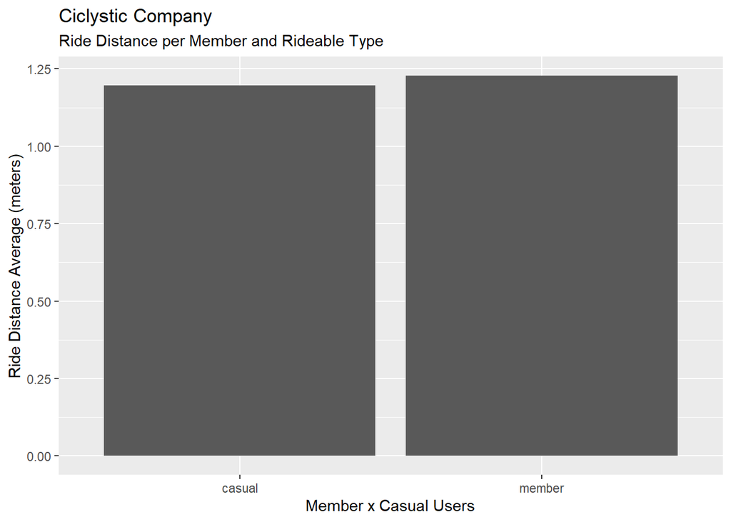

```r
# This plot shows the average distance covered per riders
#plot_ride_dist_member6 <- ggplot(ride_dist_member6, aes(member_casual, avg_dist)) +
#  geom_bar(stat = "identity", position = 'dodge') +
#  labs(title = "Ciclystic Company", subtitle = "Ride Distance per Member and Rideable Type") +
#  labs(x = "Member x Casual Users", y = "Ride Distance Average (meters)")
  plot(plot_ride_dist_member6)
```

The Average Ride Distance used by each Member Type (In KM):

```r
# This tiblle shows the average distance by bike types per riders
#ride_dist_member16 <- ciclystic_6mc %>%
#  group_by(member_casual, rideable_type) %>%
#  summarise(avg_dist = mean(ride_distance))
ride_dist_member16
```

```
## # A tibble: 4 × 3
## # Groups:   member_casual [2]
##   member_casual rideable_type avg_dist
##   <chr>         <chr>            <dbl>
## 1 casual        classic_bike      1.12
## 2 casual        electric_bike     1.26
## 3 member        classic_bike      1.06
## 4 member        electric_bike     1.38
```

And, the plot showing what average distance the members are using each type of Bike:

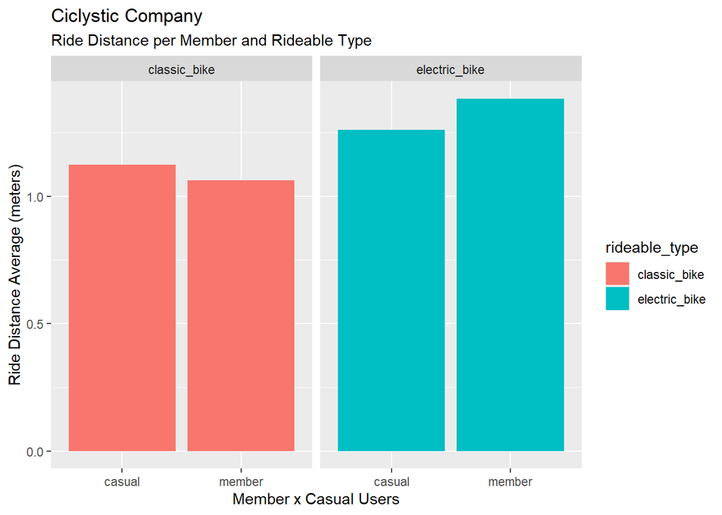

```r
# This plot shows the average average distance covered per rider by bike types
#plot_ride_dist_member16 <- ggplot(ride_dist_member16, aes(member_casual, avg_dist, fill = rideable_type)) +
#  geom_bar(stat = "identity", position = 'dodge') +
#  facet_wrap(~rideable_type) +
#  labs(title = "Ciclystic Company", subtitle = "Ride Distance per Member and Rideable Type") +
#  labs(x = "Member x Casual Users", y = "Ride Distance Average (meters)")
plot(plot_ride_dist_member16)
```

#### Analysis

Total Average Distance = 4.83 km Total Average Classic Bike = 2.19 km - 45% Total Average Eletric Bike = 2.64 km - 55% Total Average Casual User = 2.39 km - 49% Total Average Member user = 2.44 km - 51%

#### Analysis II

- For Business Days, we can invite the users to use Eletric Bikes for more commodity and quickly destiny,
- For weekends, we can invite the users to use Classic Bikes as a healty life way with the family.

## But, how is the use of the bikes and members on weekdays and weekends??

In another insight, above you can see:

How is the Average Ride Time by each Rideable Type? (In Minutes)

```r
# This tiblle shows the average time expended per bike types
#ride_avg_type6 <- ciclystic_6mc %>%
#  group_by(rideable_type) %>%
#  summarize(ride_avg = mean(ride_min))
  ride_avg_type6
```

```
## # A tibble: 2 × 2
##   rideable_type ride_avg
##   <chr>         <drtn>
## 1 classic_bike  33.40331 secs
## 2 electric_bike 23.44713 secs
```

How is the Average Ride Time by each Rideable Type and Member Type?

```r
# This tiblle shows the average time expended by riders per bike types
#ride_avg_type16 <- ciclystic_6mc %>%
#  group_by(rideable_type, member_casual) %>%
#  summarize(ride_avg = mean(ride_min))
ride_avg_type16
```

```
## # A tibble: 4 × 3
## # Groups:   rideable_type [2]
##   rideable_type member_casual ride_avg
##   <chr>         <chr>         <drtn>
## 1 classic_bike  casual        47.81599 secs
## 2 classic_bike  member        23.78167 secs
## 3 electric_bike casual        27.55327 secs
## 4 electric_bike member        20.53025 secs
```

And, the plot showing how each type of Bike are being used by Member:

```
## Defaulting to continuous.
```

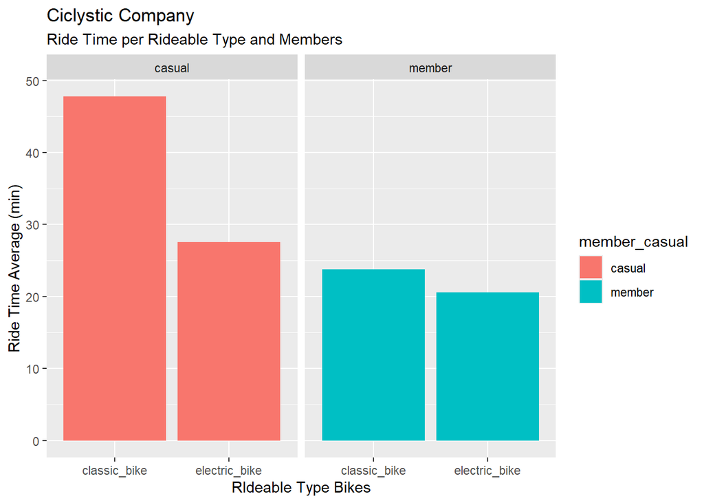

In another insight, above you can see:

How is the Average Ride Distance by each Rideable Type and Member Type?

```r
# This tiblle shows the ride distance covered by bike type per rider
#ride_dist_type16 <- ciclystic_6mc %>%
#  group_by(rideable_type, member_casual) %>%
#  summarise(avg_dist = mean(ride_distance))
  ride_dist_type16
```

```
## # A tibble: 4 × 3
## # Groups:   rideable_type [2]
##   rideable_type member_casual avg_dist
##   <chr>         <chr>            <dbl>
## 1 classic_bike  casual            1.12
## 2 classic_bike  member            1.06
## 3 electric_bike casual            1.26
## 4 electric_bike member            1.38
```

And, the plot showing what distance each type of Member are using each type of Bike:

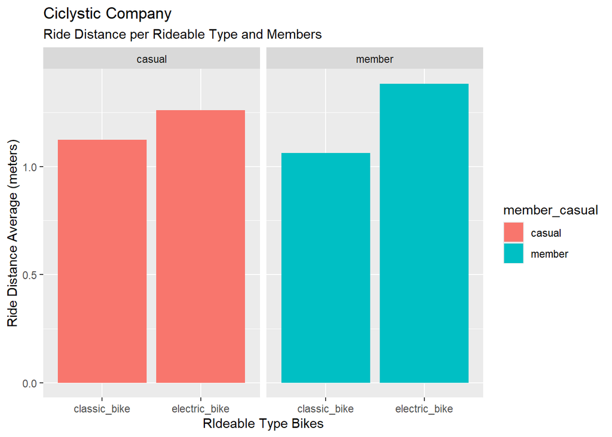

```r
# This plot shows the ride distance covered by bike types per riders
#plot_ride_dist_type16 <- ggplot(ride_dist_type16, aes(rideable_type, avg_dist, fill = member_casual)) +
#  geom_bar(stat = "identity", position = 'dodge') +
#  facet_wrap(~member_casual) +
#  labs(title = "Ciclystic Company", subtitle = "Ride Distance per Rideable Type and Members") +
#  labs(x = "RIdeable Type Bikes", y = "Ride Distance Average (meters)")
plot(plot_ride_dist_type16)
```

## Including general Plots

In these plots, you can see the points of rides per Members and Rideables Types according Latitude and Longitude:

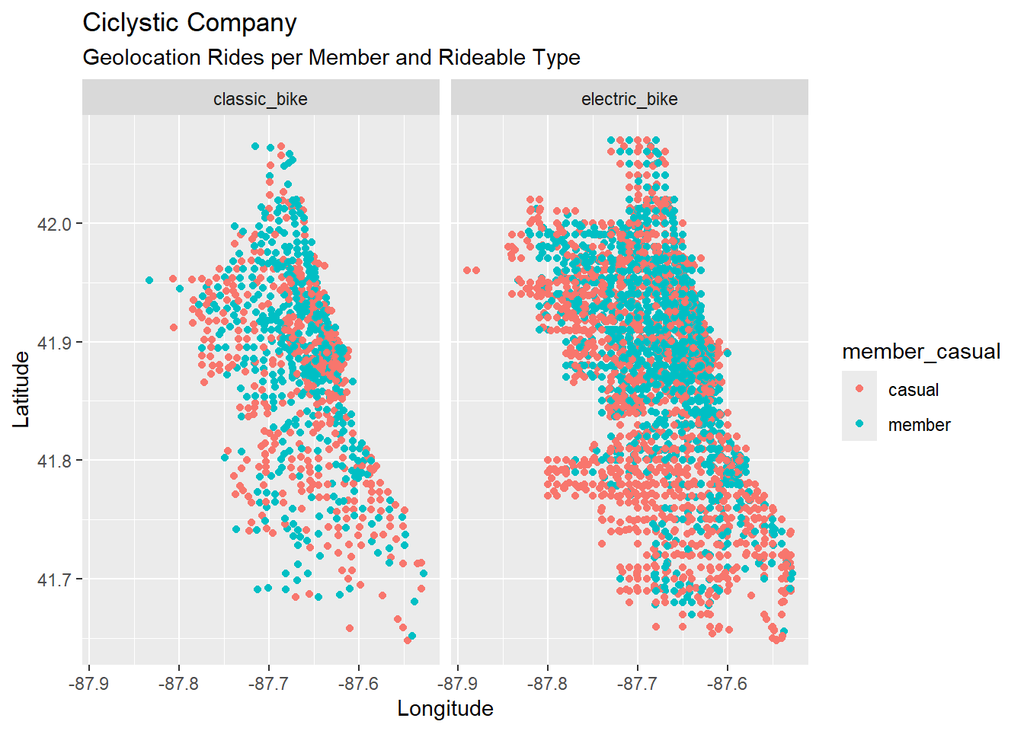

```r
# This plot shows the geolocation points per rider Type and Bike Type
#plot_gen_rides_point6 <- ggplot(ciclystic_6m) +
#  geom_point(data = ciclystic_6m, aes(x = start_lng, y = start_lat, color = member_casual)) +
#  facet_wrap(~rideable_type) +
#  labs(title = "Ciclystic Company", subtitle = "Geolocation Rides per Member and Rideable Type") +
#  labs(x = "Longitude", y = "Latitude")
plot(plot_gen_rides_point6)
```

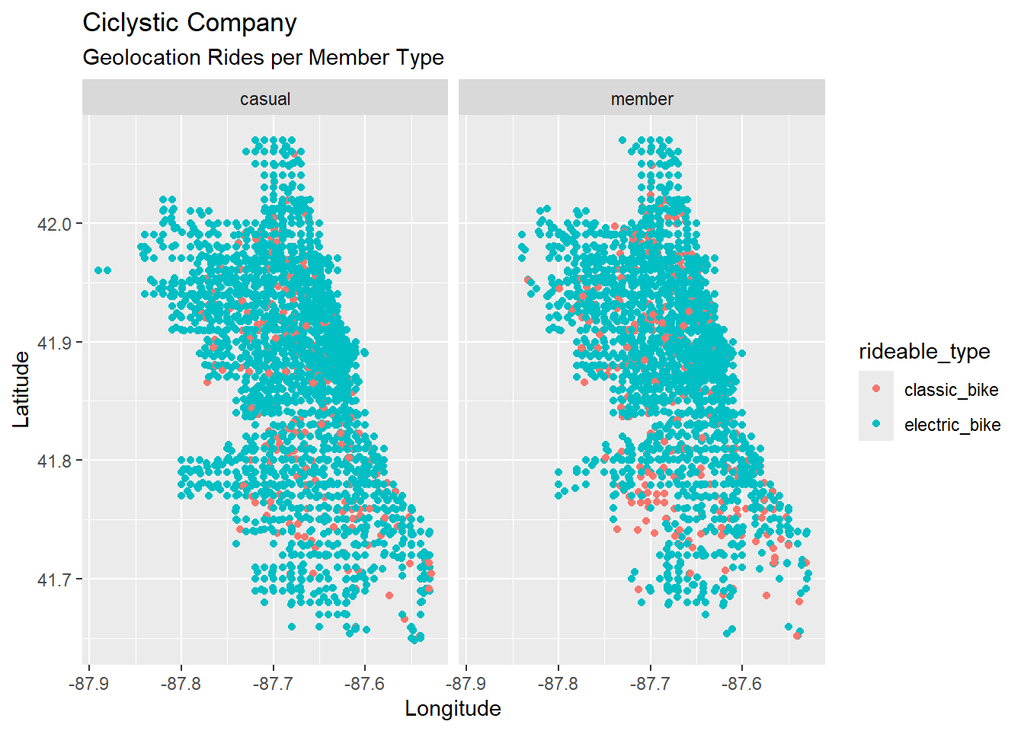

```r
# Graphic with geolocalization per Member Types
#plot_gen_rides_point6i <- ggplot(ciclystic_6m) +
#  geom_point(data = ciclystic_6m, aes(x = start_lng, y = start_lat, color = rideable_type)) +
#  facet_wrap(~member_casual) +
#  labs(title = "Ciclystic Company", subtitle = "Geolocation Rides per Member Type") +
#  labs(x = "Longitude", y = "Latitude")
  plot(plot_gen_rides_point6i)
```

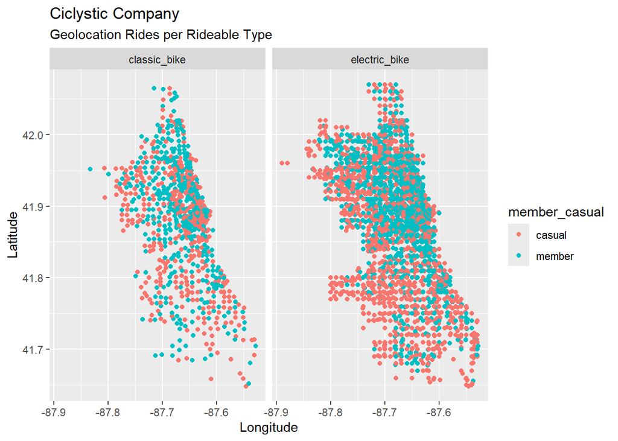

```r
# Graphic with geolocalization per Rideable Types
#plot_gen_rides_point6r <- ggplot(ciclystic_6m) +
#  geom_point(data = ciclystic_6m, aes(x = start_lng, y = start_lat, color = member_casual)) +
#  facet_wrap(~rideable_type) +
#  labs(title = "Ciclystic Company", subtitle = "Geolocation Rides per Rideable Type") +
#  labs(x = "Longitude", y = "Latitude")
  plot(plot_gen_rides_point6r)
```

### How Members and Casuals are using the Bikes on Weekdays and Weekends???

This is a good question and these results show some insights.

This is how the users are using bikes on Weekdays:(number of rides on weekdays)

```r
# This tiblle shows the numbers of rides the users are doing during weekdays per Bike Type
#rides_weekday <- cicly_weekdays %>%
#  count(member_casual, rideable_type)
  rides_weekday
```

```
##   member_casual rideable_type      n
## 1        casual  classic_bike  71239
## 2        casual electric_bike  86297
## 3        member  classic_bike 135654
## 4        member electric_bike 142090
```

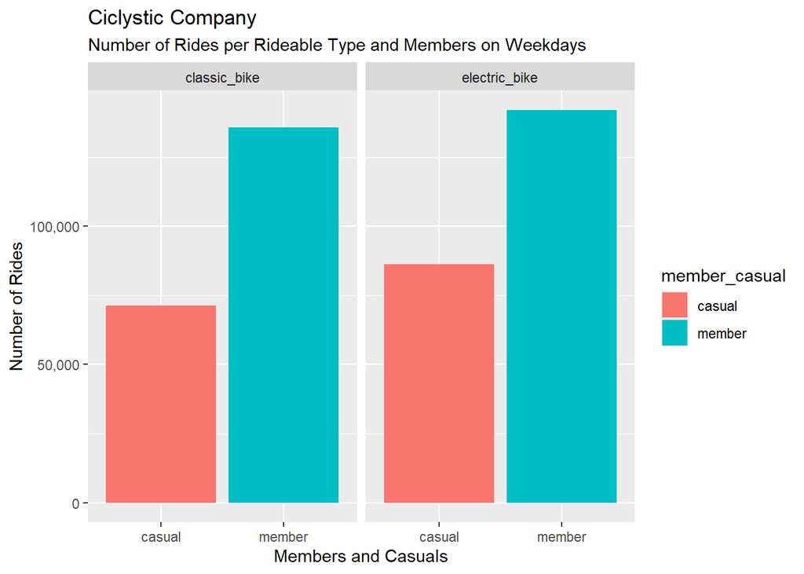

```r
#plot_rides_weekday <- ggplot(cicly_weekdays) +
#  geom_bar(aes(x = member_casual, fill = member_casual)) +
#  facet_wrap(~rideable_type) +
#  labs(title = "Ciclystic Company", subtitle = "Number of Rides per Rideable Type and Members on Weekdays") +
#  labs(x = "Members and Casuals", y = "Number of Rides")
  plot(plot_rides_weekday)
```

And, below these are the results about rides on weekends:(number of rides on weekends)

```r
# This tiblle shows the numbers of rides the users are doing during weekdays per Bike Type
#rides_weekend <- cicly_weekends %>%
#  count(member_casual, rideable_type)
  rides_weekend
```

```
##   member_casual rideable_type     n
## 1        casual  classic_bike 55197
## 2        casual electric_bike 55710
## 3        member  classic_bike 53740
## 4        member electric_bike 57816
```

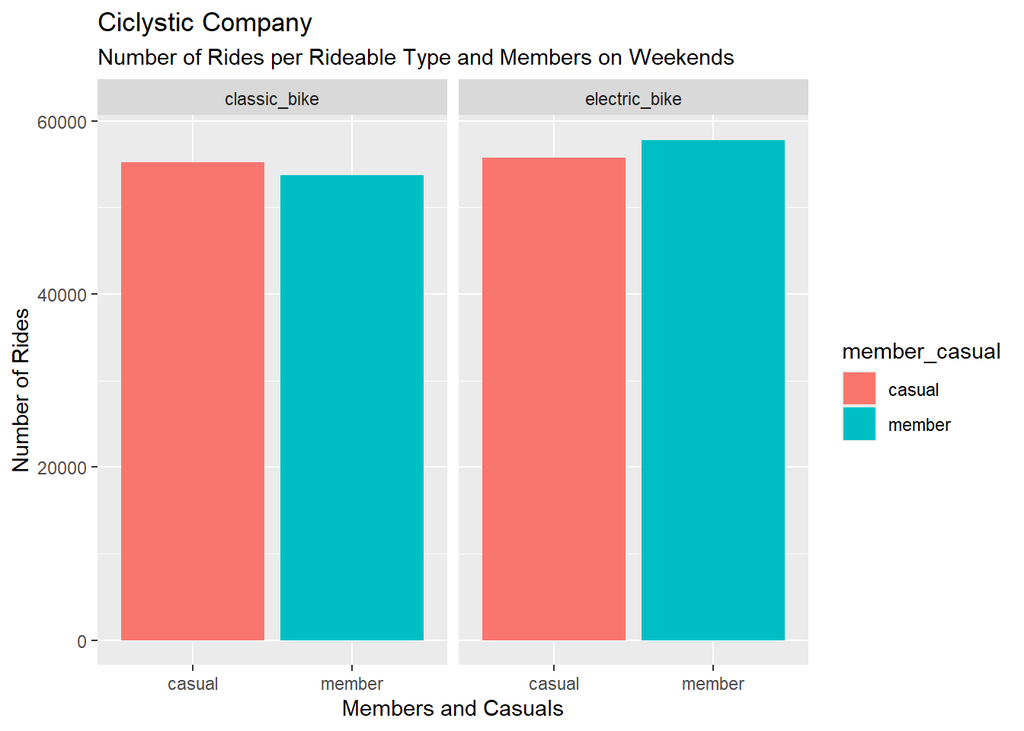

```r
#plot_rides_weekend <- ggplot(cicly_weekends) +
#  geom_bar(aes(x = member_casual, fill = member_casual)) +
#  facet_wrap(~rideable_type) +
#  labs(title = "Ciclystic Company", subtitle = "Number of Rides per Rideable Type and Members on Weekends") +
#  labs(x = "Members and Casuals", y = "Number of Rides")
  plot(plot_rides_weekend)
```